# Import Libraries

```python
import pandas as pd
import numpy as np
import matplotlib.pyplot as plt
import seaborn as sns
%matplotlib inline
from sklearn.preprocessing import MinMaxScaler
from scipy import stats
```

```python
import warnings

# Ignore all warnings
warnings.filterwarnings("ignore")
```

# Data Ingestion

```python
df=pd.read_excel('data/ameo.xlsx').copy()
df=df.iloc[:,1:]
df.head()
```

|  | ID | Salary | DOJ | DOL | Designation | JobCity | Gender | DOB | 10percentage | 10board | ... | ComputerScience | MechanicalEngg | ElectricalEngg | TelecomEngg | CivilEngg | conscientiousness | agreeableness | extraversion | nueroticism | openess_to_experience |
| --- | --- | --- | --- | --- | --- | --- | --- | --- | --- | --- | --- | --- | --- | --- | --- | --- | --- | --- | --- | --- | --- |
| 0 | 203097 | 420000 | 2012-06-01 | present | senior quality engineer | Bangalore | f | 1990-02-19 | 84.3 | board ofsecondary education,ap | ... | -1 | -1 | -1 | -1 | -1 | 0.9737 | 0.8128 | 0.5269 | 1.35490 | -0.4455 |
| 1 | 579905 | 500000 | 2013-09-01 | present | assistant manager | Indore | m | 1989-10-04 | 85.4 | cbse | ... | -1 | -1 | -1 | -1 | -1 | -0.7335 | 0.3789 | 1.2396 | -0.10760 | 0.8637 |
| 2 | 810601 | 325000 | 2014-06-01 | present | systems engineer | Chennai | f | 1992-08-03 | 85.0 | cbse | ... | -1 | -1 | -1 | -1 | -1 | 0.2718 | 1.7109 | 0.1637 | -0.86820 | 0.6721 |
| 3 | 267447 | 1100000 | 2011-07-01 | present | senior software engineer | Gurgaon | m | 1989-12-05 | 85.6 | cbse | ... | -1 | -1 | -1 | -1 | -1 | 0.0464 | 0.3448 | -0.3440 | -0.40780 | -0.9194 |
| 4 | 343523 | 200000 | 2014-03-01 | 2015-03-01 00:00:00 | get | Manesar | m | 1991-02-27 | 78.0 | cbse | ... | -1 | -1 | -1 | -1 | -1 | -0.8810 | -0.2793 | -1.0697 | 0.09163 | -0.1295 |

5 rows × 38 columns

```python
df.info()
```

```
<class 'pandas.core.frame.DataFrame'>
RangeIndex: 3998 entries, 0 to 3997
Data columns (total 38 columns):
 #   Column                 Non-Null Count  Dtype
---  ------                 --------------  -----
 0   ID                     3998 non-null   int64
 1   Salary                 3998 non-null   int64
 2   DOJ                    3998 non-null   datetime64[ns]
 3   DOL                    3998 non-null   object
 4   Designation            3998 non-null   object
 5   JobCity                3998 non-null   object
 6   Gender                 3998 non-null   object
 7   DOB                    3998 non-null   datetime64[ns]
 8   10percentage           3998 non-null   float64
 9   10board                3998 non-null   object
```

[output cut: 30 more lines]

```python
df.describe()
```

|  | ID | Salary | DOJ | DOB | 10percentage | 12graduation | 12percentage | CollegeID | CollegeTier | collegeGPA | ... | ComputerScience | MechanicalEngg | ElectricalEngg | TelecomEngg | CivilEngg | conscientiousness | agreeableness | extraversion | nueroticism | openess_to_experience |
| --- | --- | --- | --- | --- | --- | --- | --- | --- | --- | --- | --- | --- | --- | --- | --- | --- | --- | --- | --- | --- | --- |
| count | 3.998000e+03 | 3.998000e+03 | 3998 | 3998 | 3998.000000 | 3998.000000 | 3998.000000 | 3998.000000 | 3998.000000 | 3998.000000 | ... | 3998.000000 | 3998.000000 | 3998.000000 | 3998.000000 | 3998.000000 | 3998.000000 | 3998.000000 | 3998.000000 | 3998.000000 | 3998.000000 |
| mean | 6.637945e+05 | 3.076998e+05 | 2013-07-02 11:04:10.325162496 | 1990-12-06 06:01:15.637819008 | 77.925443 | 2008.087544 | 74.466366 | 5156.851426 | 1.925713 | 71.486171 | ... | 90.742371 | 22.974737 | 16.478739 | 31.851176 | 2.683842 | -0.037831 | 0.146496 | 0.002763 | -0.169033 | -0.138110 |
| min | 1.124400e+04 | 3.500000e+04 | 1991-06-01 00:00:00 | 1977-10-30 00:00:00 | 43.000000 | 1995.000000 | 40.000000 | 2.000000 | 1.000000 | 6.450000 | ... | -1.000000 | -1.000000 | -1.000000 | -1.000000 | -1.000000 | -4.126700 | -5.781600 | -4.600900 | -2.643000 | -7.375700 |
| 25% | 3.342842e+05 | 1.800000e+05 | 2012-10-01 00:00:00 | 1989-11-16 06:00:00 | 71.680000 | 2007.000000 | 66.000000 | 494.000000 | 2.000000 | 66.407500 | ... | -1.000000 | -1.000000 | -1.000000 | -1.000000 | -1.000000 | -0.713525 | -0.287100 | -0.604800 | -0.868200 | -0.669200 |
| 50% | 6.396000e+05 | 3.000000e+05 | 2013-11-01 00:00:00 | 1991-03-07 12:00:00 | 79.150000 | 2008.000000 | 74.400000 | 3879.000000 | 2.000000 | 71.720000 | ... | -1.000000 | -1.000000 | -1.000000 | -1.000000 | -1.000000 | 0.046400 | 0.212400 | 0.091400 | -0.234400 | -0.094300 |
| 75% | 9.904800e+05 | 3.700000e+05 | 2014-07-01 00:00:00 | 1992-03-13 18:00:00 | 85.670000 | 2009.000000 | 82.600000 | 8818.000000 | 2.000000 | 76.327500 | ... | -1.000000 | -1.000000 | -1.000000 | -1.000000 | -1.000000 | 0.702700 | 0.812800 | 0.672000 | 0.526200 | 0.502400 |
| max | 1.298275e+06 | 4.000000e+06 | 2015-12-01 00:00:00 | 1997-05-27 00:00:00 | 97.760000 | 2013.000000 | 98.700000 | 18409.000000 | 2.000000 | 99.930000 | ... | 715.000000 | 623.000000 | 676.000000 | 548.000000 | 516.000000 | 1.995300 | 1.904800 | 2.535400 | 3.352500 | 1.822400 |
| std | 3.632182e+05 | 2.127375e+05 | NaN | NaN | 9.850162 | 1.653599 | 10.999933 | 4802.261482 | 0.262270 | 8.167338 | ... | 175.273083 | 98.123311 | 87.585634 | 104.852845 | 36.658505 | 1.028666 | 0.941782 | 0.951471 | 1.007580 | 1.008075 |

8 rows × 29 columns

# Data Cleaning And Transformation

## Handling duplicates

```python
df.duplicated().sum()
```

```
0
```

- There are no duplicates

## Handling missing values

```python
df.isna().sum()
```

```
ID                       0
Salary                   0
DOJ                      0
DOL                      0
Designation              0
JobCity                  0
Gender                   0
DOB                      0
10percentage             0
10board                  0
12graduation             0
12percentage             0
12board                  0
CollegeID                0
CollegeTier              0
Degree                   0
Specialization           0
collegeGPA               0
CollegeCityID            0
CollegeCityTier          0
CollegeState             0
GraduationYear           0
English                  0
Logical                  0
Quant                    0
Domain                   0
ComputerProgramming      0
ElectronicsAndSemicon    0
ComputerScience          0
MechanicalEngg           0
ElectricalEngg           0
TelecomEngg              0
CivilEngg                0
conscientiousness        0
agreeableness            0
extraversion             0
nueroticism              0
openess_to_experience    0
dtype: int64
```

- There are no missing values

## Handling columns

### Salary

```python
df['Salary']
```

```
0        420000
1        500000
2        325000
3       1100000
4        200000
         ...
3993     280000
3994     100000
3995     320000
3996     200000
3997     400000
Name: Salary, Length: 3998, dtype: int64
```

```python
df['Salary'].info()
```

```
<class 'pandas.core.series.Series'>
RangeIndex: 3998 entries, 0 to 3997
Series name: Salary
Non-Null Count  Dtype
--------------  -----
3998 non-null   int64
dtypes: int64(1)
memory usage: 31.4 KB
```

```python
#convert salary in lakhs
df['Salary']=df['Salary'].apply(lambda x:x/100000)
df['Salary']
```

```
0        4.20
1        5.00
2        3.25
3       11.00
4        2.00
        ...
3993     2.80
3994     1.00
3995     3.20
3996     2.00
3997     4.00
Name: Salary, Length: 3998, dtype: float64
```

```python
df['Salary'].describe()
```

```
count    3998.000000
mean        3.076998
std         2.127375
min         0.350000
25%         1.800000
50%         3.000000
75%         3.700000
max        40.000000
Name: Salary, dtype: float64
```

```python
np.percentile(df['Salary'],99)
```

```
9.30599999999995
```

```python
clean_df=pd.DataFrame(df['Salary'][df['Salary']<6])
```

```python
num_salary_1To4=(clean_df['Salary'][(clean_df['Salary']>1)&(clean_df['Salary']<4)]).count()
(num_salary_1To4/len(df))*100
```

```
72.28614307153578
```

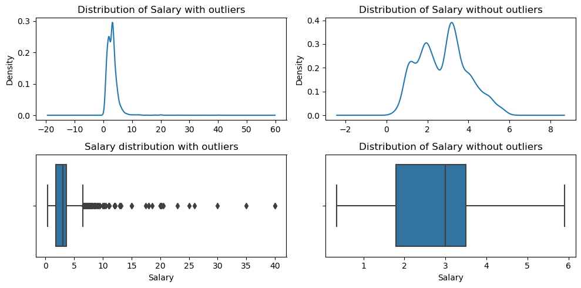

```python
plt.figure(figsize=(10,5))
plt.subplot(221)
df['Salary'].plot(kind='kde')
plt.title('Distribution of Salary with outliers')
plt.subplot(222)
clean_df['Salary'].plot(kind='kde')
plt.title('Distribution of Salary without outliers')
plt.subplot(223)
sns.boxplot(data=df,x='Salary')
plt.title('Salary distribution with outliers')
plt.subplot(224)
sns.boxplot(data=clean_df,x='Salary')
plt.title('Distribution of Salary without outliers')
plt.tight_layout()
```

#### Observation

- Maximum Salary is 40 lakh and minimum salary is 0.35 lakh
- 72% of candidates earn between 1 and 4 Lakhs and 99 % of candidates earn less than 9.3 L
- Salary with outliers is right skewed but Salary without outliers is normally distributed but is bimodal.

### DOJ

```python
df['DOJ']
```

```
0      2012-06-01
1      2013-09-01
2      2014-06-01
3      2011-07-01
4      2014-03-01
          ...
3993   2011-10-01
3994   2013-07-01
3995   2013-07-01
3996   2014-07-01
3997   2013-02-01
Name: DOJ, Length: 3998, dtype: datetime64[ns]
```

```python
years=df['DOJ'].apply(lambda x: x.year).value_counts()
clean_df['DOJ']=df['DOJ']
years
```

```
DOJ
2014    1596
2013    1004
2012     590
2011     381
2015     248
2010     166
2009       5
2007       4
2004       1
2008       1
2006       1
1991       1
Name: count, dtype: int64
```

```
 [Text(0.34254820698146204, 1.0453041308125524, '2014'),
 [Text(0.18684447653534292, 0.5701658895341194, '39.9%'),
```

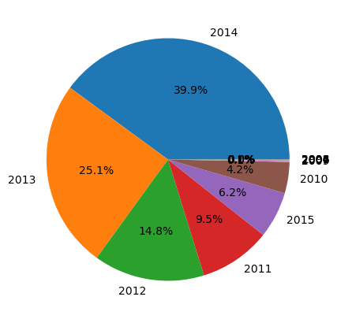

```python
plt.figure(figsize=(5,5))
plt.pie(years.to_list(),labels=years.index,autopct='%1.1f%%',)
```

#### Observation

- 39.9% joined in 2014 and only 1 person joined in following years(2004,2008,2006,1991)

### DOL

```python
df['DOL'].info()
```

```
<class 'pandas.core.series.Series'>
RangeIndex: 3998 entries, 0 to 3997
Series name: DOL
Non-Null Count  Dtype
--------------  -----
3998 non-null   object
dtypes: object(1)
memory usage: 31.4+ KB
```

```python
df['DOL'].unique()
```

```
array(['present', datetime.datetime(2015, 3, 1, 0, 0),
       datetime.datetime(2015, 5, 1, 0, 0),
       datetime.datetime(2015, 7, 1, 0, 0),
       datetime.datetime(2015, 4, 1, 0, 0),
       datetime.datetime(2014, 10, 1, 0, 0),
       datetime.datetime(2014, 9, 1, 0, 0),
       datetime.datetime(2014, 6, 1, 0, 0),
       datetime.datetime(2012, 9, 1, 0, 0),
       datetime.datetime(2013, 12, 1, 0, 0),
       datetime.datetime(2015, 6, 1, 0, 0),
       datetime.datetime(2013, 10, 1, 0, 0),
       datetime.datetime(2015, 1, 1, 0, 0),
       datetime.datetime(2014, 4, 1, 0, 0),
       datetime.datetime(2013, 6, 1, 0, 0),
       datetime.datetime(2012, 3, 1, 0, 0),
       datetime.datetime(2014, 7, 1, 0, 0),
       datetime.datetime(2013, 2, 1, 0, 0),
       datetime.datetime(2014, 1, 1, 0, 0),
       datetime.datetime(2013, 4, 1, 0, 0),
       datetime.datetime(2012, 7, 1, 0, 0),
       datetime.datetime(2014, 5, 1, 0, 0),
       datetime.datetime(2013, 9, 1, 0, 0),
       datetime.datetime(2015, 2, 1, 0, 0),
       datetime.datetime(2012, 1, 1, 0, 0),
       datetime.datetime(2015, 8, 1, 0, 0),
       datetime.datetime(2014, 8, 1, 0, 0),
       datetime.datetime(2015, 12, 1, 0, 0),
       datetime.datetime(2014, 12, 1, 0, 0),
       datetime.datetime(2012, 5, 1, 0, 0),
       datetime.datetime(2011, 3, 1, 0, 0),
       datetime.datetime(2011, 7, 1, 0, 0),
       datetime.datetime(2014, 2, 1, 0, 0),
       datetime.datetime(2011, 12, 1, 0, 0),
       datetime.datetime(2015, 10, 1, 0, 0),
       datetime.datetime(2014, 11, 1, 0, 0),
       datetime.datetime(2014, 3, 1, 0, 0),
       datetime.datetime(2011, 11, 1, 0, 0),
       datetime.datetime(2013, 5, 1, 0, 0),
       datetime.datetime(2013, 7, 1, 0, 0),
       datetime.datetime(2013, 11, 1, 0, 0),
```

[output cut: 11 more lines]

```
       datetime.datetime(2013, 1, 1, 0, 0),
       datetime.datetime(2011, 6, 1, 0, 0),
       datetime.datetime(2015, 9, 1, 0, 0),
       datetime.datetime(2012, 4, 1, 0, 0),
       datetime.datetime(2012, 8, 1, 0, 0),
       datetime.datetime(2011, 4, 1, 0, 0),
       datetime.datetime(2011, 10, 1, 0, 0),
       datetime.datetime(2015, 11, 1, 0, 0),
       datetime.datetime(2012, 12, 1, 0, 0),
       datetime.datetime(2011, 9, 1, 0, 0),
       datetime.datetime(2010, 8, 1, 0, 0),
       datetime.datetime(2011, 8, 1, 0, 0),
       datetime.datetime(2009, 6, 1, 0, 0),
       datetime.datetime(2008, 3, 1, 0, 0),
       datetime.datetime(2010, 10, 1, 0, 0)], dtype=object)
```

```python
(df['DOL']=='present').sum()
```

```
1875
```

```python
def replacePresent(x):
    if x=='present':
        return pd.to_datetime('2050-12-31',format='%Y-%m-%d')
    return x

df['DOL']=df['DOL'].apply(replacePresent)
df['DOL'].value_counts()
```

```
DOL
2050-12-31    1875
2015-04-01     573
2015-03-01     124
2015-05-01     112
2015-01-01      99
              ...
2005-03-01       1
2015-10-01       1
2010-02-01       1
2011-02-01       1
2010-10-01       1
Name: count, Length: 67, dtype: int64
```

```python
clean_df['DOL']=df['DOL']
df['DOL'].info()
```

```
<class 'pandas.core.series.Series'>
RangeIndex: 3998 entries, 0 to 3997
Series name: DOL
Non-Null Count  Dtype
--------------  -----
3998 non-null   datetime64[ns]
dtypes: datetime64[ns](1)
memory usage: 31.4 KB
```

```
 [Text(0.10701240624020007, 1.0947823276390072, '2050'),
 [Text(0.05837040340374549, 0.5971539968940038, '46.9%'),
```

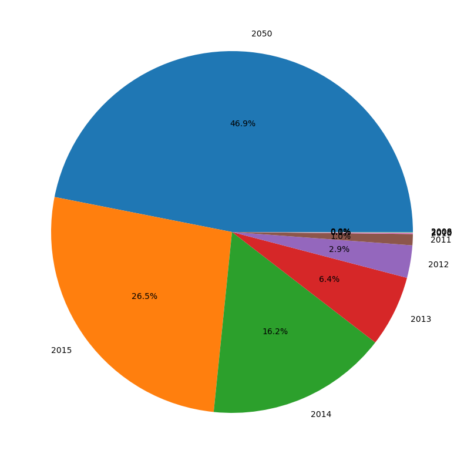

```python
y=df['DOL'].apply(lambda x:x.year)
plt.figure(figsize=(10,10))
plt.pie(x=y.value_counts().to_list(),labels=y.value_counts().index,autopct='%1.1f%%')
```

#### Observation

- 46.9% of candidates assumed to be still working in their companies
- 26.5% candidates left company in 2015

### Designation

```python
df['Designation'].value_counts()
```

```
Designation
software engineer                    539
software developer                   265
system engineer                      205
programmer analyst                   139
systems engineer                     118
                                    ...
cad drafter                            1
noc engineer                           1
human resources intern                 1
senior quality assurance engineer      1
jr. software developer                 1
Name: count, Length: 419, dtype: int64
```

```python
df['Designation'].value_counts()
```

```
Designation
software engineer                    539
software developer                   265
system engineer                      205
programmer analyst                   139
systems engineer                     118
                                    ...
cad drafter                            1
noc engineer                           1
human resources intern                 1
senior quality assurance engineer      1
jr. software developer                 1
Name: count, Length: 419, dtype: int64
```

```python
clean_df['Designation']=df['Designation']
df['Designation'].value_counts()[:15]
```

```
Designation
software engineer             539
software developer            265
system engineer               205
programmer analyst            139
systems engineer              118
java software engineer        111
software test engineer        100
project engineer               77
technical support engineer     76
senior software engineer       72
java developer                 67
test engineer                  57
web developer                  54
application developer          52
assistant manager              52
Name: count, dtype: int64
```

```python
# Percentage of candidates who are working in these top 15 job roles
(df['Designation'].value_counts()[:15].sum()/len(df))*100
```

```
49.6248124062031
```

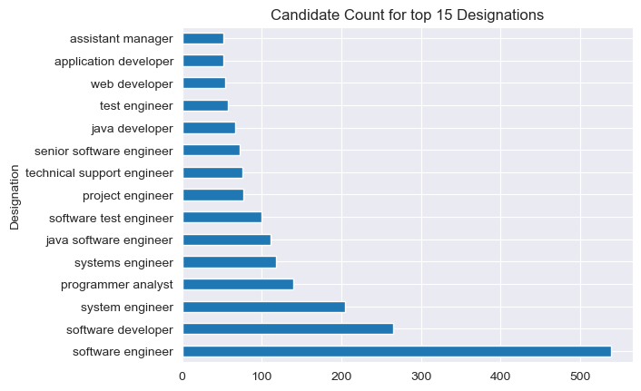

```python
sns.set_style('darkgrid')
plt.title('Candidate Count for top 15 Designations')
df['Designation'].value_counts()[:15].plot(kind='barh')
```

#### Observation

- There are 390+ unique job roles
- 49.62 % of candidates are working in these 15 designations most notably as software engineer.

### Job City

```python
df['JobCity']
```

```
0              Bangalore
1                 Indore
2                Chennai
3                Gurgaon
4                Manesar
              ...
3993          New Delhi
3994           Hyderabad
3995           Bangalore
3996    Asifabadbanglore
3997             Chennai
Name: JobCity, Length: 3998, dtype: object
```

```python
df['JobCity'].value_counts()
```

```
JobCity
Bangalore           627
-1                  461
Noida               368
Hyderabad           335
Pune                290
                   ...
Tirunelvelli          1
Ernakulam             1
Nanded                1
Dharmapuri            1
Asifabadbanglore      1
Name: count, Length: 339, dtype: int64
```

```python
df['JobCity']=df['JobCity'].str.lower().str.strip()
clean_df['JobCity']=df['JobCity']
df['JobCity'].unique()
```

```
array(['bangalore', 'indore', 'chennai', 'gurgaon', 'manesar',
       'hyderabad', 'banglore', 'noida', 'kolkata', 'pune', nan, 'mohali',
       'jhansi', 'delhi', 'bhubaneswar', 'navi mumbai', 'mumbai',
       'new delhi', 'mangalore', 'rewari', 'gaziabaad', 'bhiwadi',
       'mysore', 'rajkot', 'greater noida', 'jaipur', 'thane',
       'maharajganj', 'thiruvananthapuram', 'punchkula', 'bhubaneshwar',
       'coimbatore', 'dhanbad', 'lucknow', 'trivandrum', 'gandhi nagar',
       'una', 'daman and diu', 'gurgoan', 'vsakhapttnam', 'nagpur',
       'bhagalpur', 'new delhi - jaisalmer', 'ahmedabad', 'kochi/cochin',
       'bankura', 'bengaluru', 'kanpur', 'vijayawada', 'kochi', 'beawar',
       'alwar', 'siliguri', 'raipur', 'bhopal', 'faridabad', 'jodhpur',
       'udaipur', 'muzaffarpur', 'kolkata`', 'bulandshahar', 'haridwar',
       'raigarh', 'visakhapatnam', 'jabalpur', 'unnao', 'aurangabad',
       'belgaum', 'dehradun', 'rudrapur', 'jamshedpur', 'vizag', 'nouda',
       'dharamshala', 'banagalore', 'hissar', 'ranchi', 'madurai',
       'gurga', 'chandigarh', 'australia', 'cheyyar', 'sonepat',
       'ghaziabad', 'pantnagar', 'jagdalpur', 'angul', 'baroda',
       'ariyalur', 'jowai', 'kochi/cochin, chennai and coimbatore',
       'neemrana', 'tirupathi', 'bhubneshwar', 'calicut', 'gandhinagar',
       'dubai', 'ahmednagar', 'nashik', 'bellary', 'ludhiana',
       'muzaffarnagar', 'gagret', 'indirapuram, ghaziabad', 'gwalior',
       'chennai & mumbai', 'rajasthan', 'sonipat', 'bareli', 'hospete',
       'miryalaguda', 'dharuhera', 'meerut', 'ganjam', 'hubli', 'ncr',
       'agra', 'trichy', 'kudankulam ,tarapur', 'ongole', 'sambalpur',
       'pondicherry', 'bundi', 'sadulpur,rajgarh,distt-churu,rajasthan',
       'am', 'bikaner', 'vadodara', 'india', 'asansol', 'tirunelvelli',
       'ernakulam', 'bilaspur', 'chandrapur', 'nanded', 'dharmapuri',
       'vandavasi', 'rohtak', 'patna', 'salem', 'nasikcity',
       'technopark, trivandrum', 'bharuch', 'tornagallu', 'jaspur',
       'burdwan', 'shimla', 'gajiabaad', 'jammu', 'shahdol',
       'muvattupuzha', 'al jubail,saudi arabia', 'kalmar, sweden',
       'secunderabad', 'a-64,sec-64,noida', 'ratnagiri', 'jhajjar',
       'gulbarga', 'hyderabad(bhadurpally)', 'nalagarh',
       'jeddah saudi arabia', 'chennai, bangalore', 'jamnagar',
       'tirupati', 'gonda', 'orissa', 'kharagpur',
       'navi mumbai , hyderabad', 'joshimath', 'bathinda', 'johannesburg',
       'kala amb', 'karnal', 'london', 'kota', 'panchkula', 'baddi hp',
       'nagari', 'mettur, tamil nadu', 'durgapur', 'pondi', 'surat',
       'kurnool', 'kolhapur', 'bhilai', 'hderabad', 'bahadurgarh',
       'rayagada, odisha', 'kakinada', 'varanasi', 'punr', 'nellore',
       'sahibabad', 'howrah', 'trichur', 'ambala', 'khopoli', 'keral',
       'roorkee', 'allahabad', 'delhi/ncr', 'jalandhar', 'vapi', 'pilani',
       'muzzafarpur', 'ras al khaimah', 'bihar', 'singaruli', 'pondy',
       'phagwara', 'guragaon', 'baripada', 'yamuna nagar', 'shahibabad',
       'sampla', 'guwahati', 'rourkela', 'banaglore', 'vellore', 'dausa',
       'latur (maharashtra )', 'mainpuri', 'dammam', 'haldia',
       'rae bareli', 'patiala', 'gorakhpur', 'new dehli', 'ambala city',
       'karad', 'rajpura', 'haryana', 'asifabadbanglore'], dtype=object)
```

```python
df['JobCity'].isna().sum()
```

```
461
```

```python
df['JobCity'].value_counts()[:10]
```

```
JobCity
bangalore    665
noida        389
hyderabad    368
pune         327
chennai      313
gurgaon      217
new delhi    204
kolkata      119
mumbai       119
jaipur        53
Name: count, dtype: int64
```

```python
(df['JobCity'].value_counts()[:10].sum()/len(df))*100
```

```
69.38469234617308
```

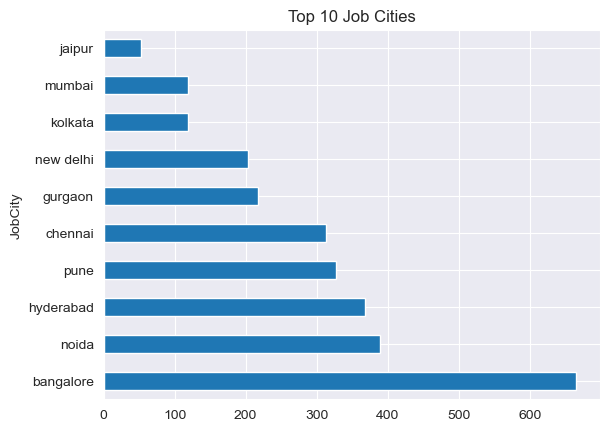

```python
sns.set_style('darkgrid')
plt.title('Top 10 Job Cities')
df['JobCity'].value_counts()[:10].plot(kind='barh')
```

#### Observations

- 69.4% of candidates work in top 10 cities
- Banglore is the most popular career destination for candidates

### Gender

```python
clean_df['Gender']=df['Gender']
df['Gender'].value_counts()
```

```
Gender
m    3041
f     957
Name: count, dtype: int64
```

```
 [Text(-0.803354993182058, 0.7514125065032227, 'm'),
 [Text(-0.4381936326447589, 0.40986136718357596, '76.1%'),
```

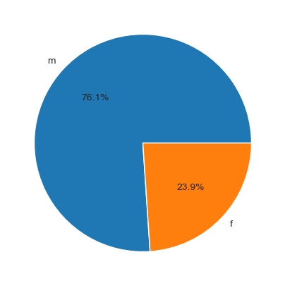

```python
plt.figure(figsize=(5,5))
plt.pie(df['Gender'].value_counts().to_list(),labels=df['Gender'].value_counts().index,autopct='%1.1f%%',)
```

#### Observation

- 76.1% of candidates are male
- 23.9% candidates are female

### DOB

```python
clean_df['DOB']=df['DOB']
df['DOB']
```

```
0      1990-02-19
1      1989-10-04
2      1992-08-03
3      1989-12-05
4      1991-02-27
          ...
3993   1987-04-15
3994   1992-08-27
3995   1991-07-03
3996   1992-03-20
3997   1991-02-26
Name: DOB, Length: 3998, dtype: datetime64[ns]
```

```
 [Text(0.7902456431886813, 0.765187443324384, '1991'),
 [Text(0.43104307810291703, 0.4173749690860276, '24.5%'),
```

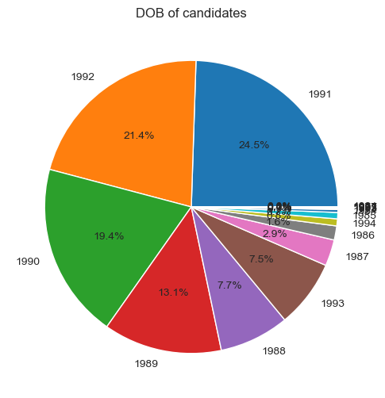

```python
years=df['DOB'].apply(lambda x:x.year)
plt.figure(figsize=(6,6))
plt.title('DOB of candidates')
plt.pie(x=years.value_counts().to_list(),labels=years.value_counts().index,autopct='%1.1f%%')
```

### 10Percentage

```python
df['10percentage']
```

```
0       84.30
1       85.40
2       85.00
3       85.60
4       78.00
        ...
3993    52.09
3994    90.00
3995    81.86
3996    78.72
3997    70.60
Name: 10percentage, Length: 3998, dtype: float64
```

```python
df['10percentage'].describe()
```

```
count    3998.000000
mean       77.925443
std         9.850162
min        43.000000
25%        71.680000
50%        79.150000
75%        85.670000
max        97.760000
Name: 10percentage, dtype: float64
```

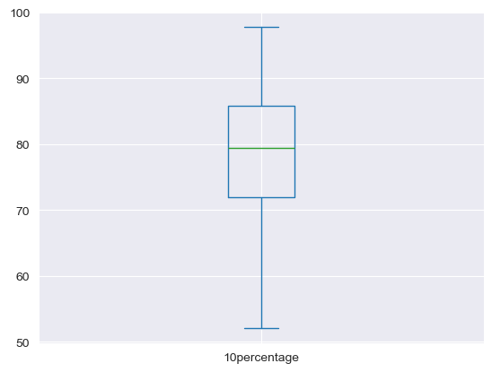

```python
clean_df['10percentage']=df['10percentage'][df['10percentage']>52]
df['10percentage'][df['10percentage']>52].plot(kind='box')
```

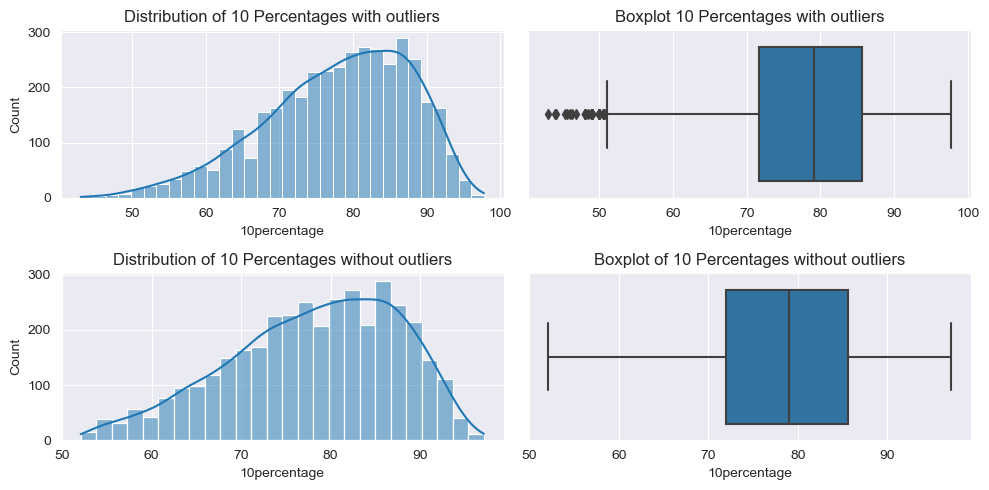

```python
plt.figure(figsize=(10,5))
plt.subplot(221)
plt.title('Distribution of 10 Percentages with outliers')
sns.histplot(x=df['10percentage'],kde=True)
plt.subplot(222)
plt.title('Boxplot 10 Percentages with outliers')
sns.boxplot(x=df['10percentage'])
plt.subplot(223)
plt.title('Distribution of 10 Percentages without outliers')
sns.histplot(x=clean_df['10percentage'],kde=True)
plt.subplot(224)
plt.title('Boxplot of 10 Percentages without outliers')
sns.boxplot(x=clean_df['10percentage'])
plt.tight_layout()
```

#### Observations

- Minimum percentage is 43% and max is 97.7%
- % are left skewed, means most candidates scored more than 60

### 10board

```python
df['10board'].unique()[:10]
```

```
array(['board ofsecondary education,ap', 'cbse', 'state board',
       'mp board bhopal', 'icse',
       'karnataka secondary school of examination', 'up',
       'karnataka state education examination board', 'ssc',
       'kerala state technical education'], dtype=object)
```

```python
def filterBoards(x):
    try:
        if x==0:
            return 'Not Specified'
        x=x.lower().strip()
        if 'cbse' in x or 'central' in x:
            return 'CBSE'
        return 'State Board'
    except Exception as e:
        print(x)
```

```python
df['10board']=df['10board'].apply(filterBoards)
clean_df['10board']=df['10board']
df['10board'].value_counts()
```

```
10board
State Board      2235
CBSE             1413
Not Specified     350
Name: count, dtype: int64
```

```
 [Text(-0.20282415745552423, 1.0811393810015695, 'State Board'),
 [Text(-0.11063135861210412, 0.5897123896372197, '55.9%'),
```

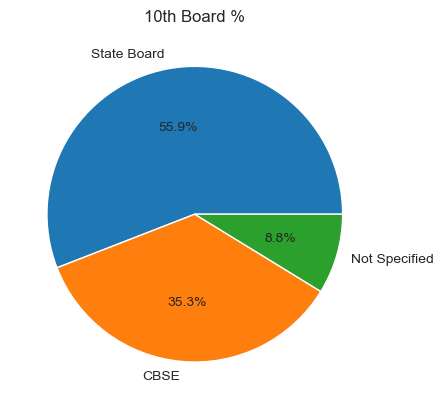

```python
plt.title('10th Board %')
plt.pie(x=df['10board'].value_counts().to_list(),labels=df['10board'].value_counts().index,autopct='%1.1f%%')
```

#### Observations

- 35.3% of candidates belong to CBSE and 55.9% belong to State Board
- 8.8% candidates have not shared their 10th board

### 12percentage

```python
df['12percentage'].describe()
```

```
count    3998.000000
mean       74.466366
std        10.999933
min        40.000000
25%        66.000000
50%        74.400000
75%        82.600000
max        98.700000
Name: 12percentage, dtype: float64
```

```python
clean_df['12percentage']=df['12percentage'][df['12percentage']>41]
```

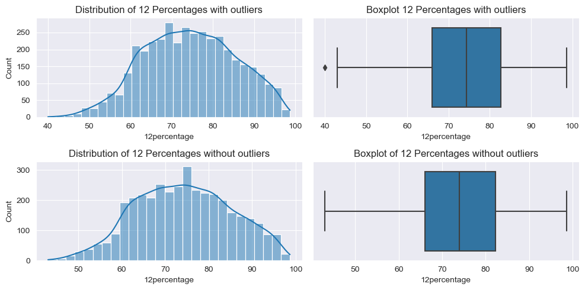

```python
plt.figure(figsize=(10,5))
plt.subplot(221)
plt.title('Distribution of 12 Percentages with outliers')
sns.histplot(x=df['12percentage'],kde=True)
plt.subplot(222)
plt.title('Boxplot 12 Percentages with outliers')
sns.boxplot(x=df['12percentage'])
plt.subplot(223)
plt.title('Distribution of 12 Percentages without outliers')
sns.histplot(x=clean_df['12percentage'],kde=True)
plt.subplot(224)
plt.title('Boxplot of 12 Percentages without outliers')
sns.boxplot(x=clean_df['12percentage'])
plt.tight_layout()
```

#### Observation

- Minimum is 40% and max is 98.7%
- Distribution is little leftskewed which is good

### 12board

```python
df['12board'].unique()[:10]
```

```
array(['board of intermediate education,ap', 'cbse', 'state board',
       'mp board', 'isc', 'icse', 'karnataka pre university board', 'up',
       'p u board, karnataka', 'dept of pre-university education'],
      dtype=object)
```

```python
def filterBoards(x):
    try:
        if x==0:
            return 'Not Specified'
        x=x.lower().strip()
        if 'cbse' in x or 'central' in x:
            return 'CBSE'
        return 'State Board'
    except Exception as e:
        print(x)
```

```python
df['12board']=df['12board'].apply(filterBoards)
clean_df['12board']=df['12board']
df['12board'].value_counts()
```

```
12board
State Board      2224
CBSE             1415
Not Specified     359
Name: count, dtype: int64
```

```
 [Text(-0.19347153400918887, 1.0828521438904442, 'State Board'),
 [Text(-0.10552992764137574, 0.5906466239402423, '55.6%'),
```

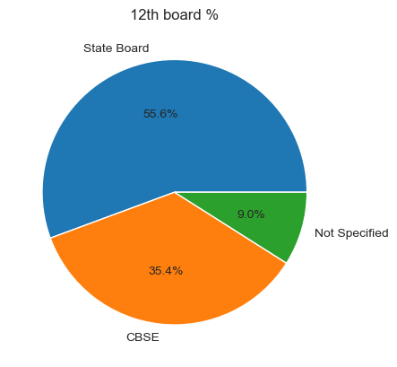

```python
plt.title('12th board %')
plt.pie(x=df['12board'].value_counts().to_list(),labels=df['12board'].value_counts().index,autopct='%1.1f%%')
```

### CollegeID

```python
df['CollegeID']
# No need
```

```
0        1141
1        5807
2          64
3        6920
4       11368
        ...
3993     6268
3994     4883
3995     9786
3996      979
3997     6609
Name: CollegeID, Length: 3998, dtype: int64
```

### College Tier

```python
df['CollegeTier'].unique()
```

```
array([2, 1], dtype=int64)
```

```python
df['CollegeTier']=df['CollegeTier'].map({1:'Tier 1',2:'Tier 2'})
clean_df['CollegeTier']=df['CollegeTier']
clean_df['CollegeTier'].value_counts()
```

[output not shown]

```
 [Text(-1.070179333470586, 0.2543937778571886, 'Tier 2'),
 [Text(-0.5837341818930468, 0.1387602424675574, '92.6%'),
```

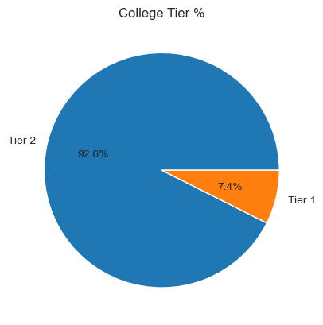

```python
plt.title('College Tier %')
plt.pie(x=df['CollegeTier'].value_counts().to_list(),labels=df['CollegeTier'].value_counts().index,autopct='%1.1f%%')
```

### Degree

```python
clean_df['Degree']=df['Degree']
df['Degree'].value_counts()
```

```
Degree
B.Tech/B.E.      3700
MCA               243
M.Tech./M.E.       53
M.Sc. (Tech.)       2
Name: count, dtype: int64
```

```
 [Text(-1.0699790741636042, 0.2552347563557841, 'B.Tech/B.E.'),
 [Text(-0.5836249495437841, 0.13921895801224585, '92.5%'),
```

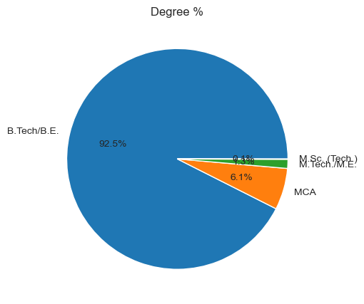

```python
plt.figure(figsize=(5,15))
plt.title('Degree %')
plt.pie(x=df['Degree'].value_counts().to_list(),labels=df['Degree'].value_counts().index,autopct='%1.1f%%')
```

### Specialization

```python
clean_df['Specialization']=df['Specialization']
df['Specialization'].value_counts()
```

```
Specialization
electronics and communication engineering      880
computer science & engineering                 744
information technology                         660
computer engineering                           600
computer application                           244
mechanical engineering                         201
electronics and electrical engineering         196
electronics & telecommunications               121
electrical engineering                          82
electronics & instrumentation eng               32
civil engineering                               29
electronics and instrumentation engineering     27
information science engineering                 27
instrumentation and control engineering         20
electronics engineering                         19
biotechnology                                   15
other                                           13
industrial & production engineering             10
applied electronics and instrumentation          9
chemical engineering                             9
computer science and technology                  6
telecommunication engineering                    6
mechanical and automation                        5
automobile/automotive engineering                5
instrumentation engineering                      4
mechatronics                                     4
aeronautical engineering                         3
electronics and computer engineering             3
electrical and power engineering                 2
biomedical engineering                           2
information & communication technology           2
industrial engineering                           2
computer science                                 2
metallurgical engineering                        2
power systems and automation                     1
control and instrumentation engineering          1
mechanical & production engineering              1
embedded systems technology                      1
polymer technology                               1
computer and communication engineering           1
information science                              1
internal combustion engine                       1
computer networking                              1
ceramic engineering                              1
electronics                                      1
industrial & management engineering              1
Name: count, dtype: int64
```

```
 [Text(0.8473220811965028, 0.7014594006190432, 'electronics and communication engineering'),
 [Text(0.4621756806526378, 0.3826142185194781, '22.0%'),
```

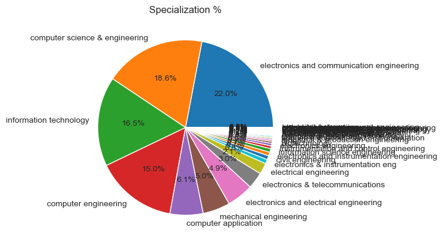

```python
plt.title('Specialization %')
plt.pie(x=df['Specialization'].value_counts().to_list(),labels=df['Specialization'].value_counts().index,autopct='%1.1f%%')
```

### CollegeGPA

```python
df.rename(columns={'collegeGPA':'CollegeGPA'},inplace=True)
df['CollegeGPA']
```

```
0       78.00
1       70.06
2       70.00
3       74.64
4       73.90
        ...
3993    61.50
3994    77.30
3995    70.00
3996    70.42
3997    68.00
Name: CollegeGPA, Length: 3998, dtype: float64
```

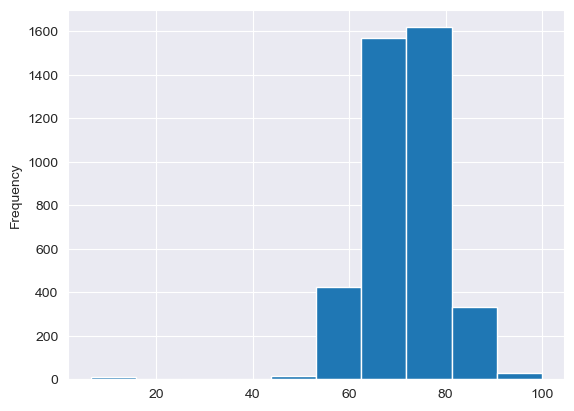

```python
df['CollegeGPA'].plot(kind='hist')
# Need to convert entries in 100 point scale to 10 point scale
```

```python
def toGPA(x):
    if x>11:
        return x/10
    return x
```

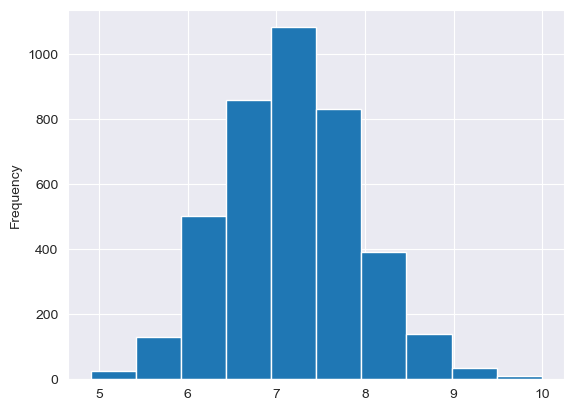

```python
df['CollegeGPA'].apply(toGPA).plot(kind='hist')
```

```python
df['CollegeGPA'].apply(toGPA).describe()
```

```
count    3998.000000
mean        7.169573
std         0.740663
min         4.907000
25%         6.650500
50%         7.180000
75%         7.640000
max         9.993000
Name: CollegeGPA, dtype: float64
```

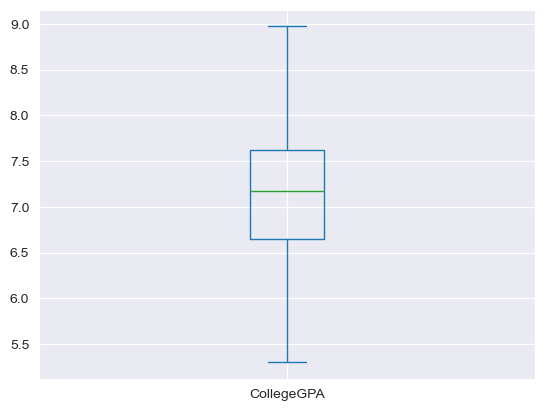

```python
df['CollegeGPA']=df['CollegeGPA'].apply(toGPA)
clean_df['CollegeGPA']=df['CollegeGPA'][(df['CollegeGPA']<9)&(df['CollegeGPA']>5.2)]
df['CollegeGPA'][(df['CollegeGPA']<9)&(df['CollegeGPA']>5.2)].plot(kind='box')
```

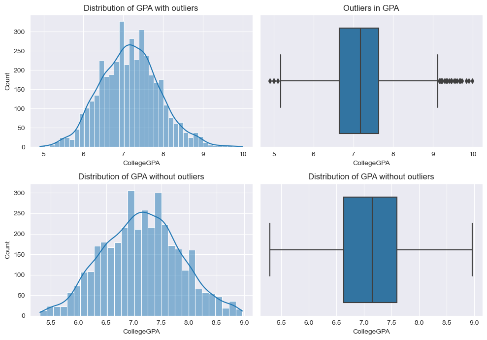

```python
plt.figure(figsize=(10,7))
plt.subplot(221)
plt.title('Distribution of GPA with outliers')
sns.histplot(x=df['CollegeGPA'],kde=True)
plt.subplot(222)
plt.title('Outliers in GPA')
sns.boxplot(x=df['CollegeGPA'])
plt.subplot(223)
plt.title('Distribution of GPA without outliers')
sns.histplot(x=clean_df['CollegeGPA'],kde=True)
plt.subplot(224)
plt.title('Distribution of GPA without outliers')
sns.boxplot(x=clean_df['CollegeGPA'])
plt.tight_layout()
```

#### Observation

```python
df['CollegeGPA'].describe()
```

```
count    3998.000000
mean        7.169573
std         0.740663
min         4.907000
25%         6.650500
50%         7.180000
75%         7.640000
max         9.993000
Name: CollegeGPA, dtype: float64
```

### CollegeCityTier

```python
df['CollegeCityTier'].value_counts()
```

```
CollegeCityTier
0    2797
1    1201
Name: count, dtype: int64
```

```python
df['CollegeCityTier']=df['CollegeCityTier'].map({0:'Tier 2',1:'Tier 1'})
clean_df['CollegeCityTier']=df['CollegeCityTier']
df['CollegeCityTier'].value_counts()
```

```
CollegeCityTier
Tier 2    2797
Tier 1    1201
Name: count, dtype: int64
```

```
 [Text(-0.645444409814041, 0.8907308874400867, 'Tier 2'),
 [Text(-0.3520605871712951, 0.4858532113309563, '70.0%'),
```

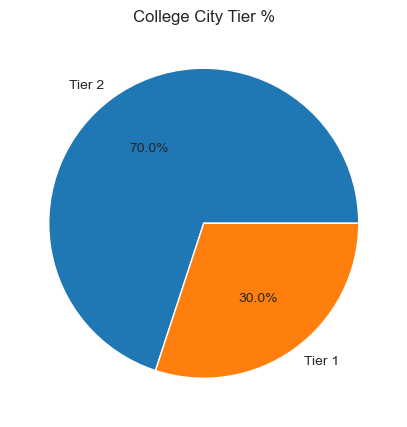

```python
plt.figure(figsize=(5,15))
plt.title('College City Tier %')
plt.pie(x=df['CollegeCityTier'].value_counts().to_list(),labels=df['CollegeCityTier'].value_counts().index,autopct='%1.1f%%')
```

### CollegeState

```python
df['CollegeState'].unique()
```

```
array(['Andhra Pradesh', 'Madhya Pradesh', 'Uttar Pradesh', 'Delhi',
       'Karnataka', 'Tamil Nadu', 'West Bengal', 'Maharashtra', 'Haryana',
       'Telangana', 'Orissa', 'Punjab', 'Kerala', 'Gujarat', 'Rajasthan',
       'Chhattisgarh', 'Uttarakhand', 'Jammu and Kashmir', 'Jharkhand',
       'Himachal Pradesh', 'Bihar', 'Assam', 'Goa', 'Sikkim',
       'Union Territory', 'Meghalaya'], dtype=object)
```

```
 [Text(0.8277120691686681, 0.7244948105766682, 'Uttar Pradesh'),
 [Text(0.45147931045563705, 0.3951789875872735, '22.9%'),
```

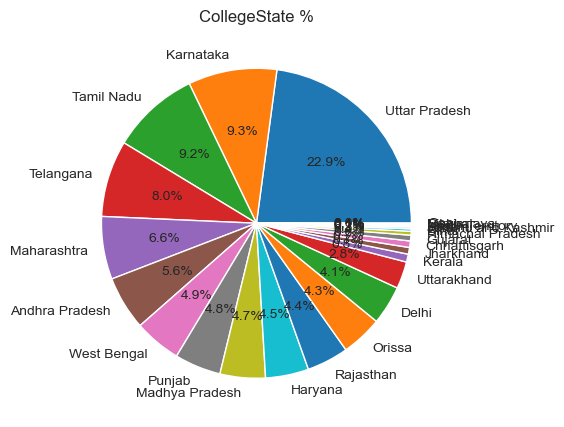

```python
clean_df['CollegeState']=df[['CollegeState']]
plt.figure(figsize=(5,15))
plt.title('CollegeState %')
plt.pie(x=df['CollegeState'].value_counts().to_list(),labels=df['CollegeState'].value_counts().index,autopct='%1.1f%%')
```

### GraduationYear

```python
df['GraduationYear'].value_counts()
```

```
GraduationYear
2013    1181
2014    1036
2012     847
2011     507
2010     292
2015      94
2009      24
2017       8
2016       7
0          1
2007       1
Name: count, dtype: int64
```

```python
clean_df['GraduationYear']=(df['GraduationYear'][df['GraduationYear']!=0]).astype(int)
clean_df['GraduationYear'].value_counts()
```

```
GraduationYear
2013.0    1146
2014.0    1015
2012.0     819
2011.0     461
2010.0     242
2015.0      89
2009.0      18
2017.0       8
2016.0       7
2007.0       1
Name: count, dtype: int64
```

```
 [Text(0.6593626871041788, 0.8804776242782988, '2013'),
 [Text(0.35965237478409745, 0.4802605223336175, '29.5%'),
```

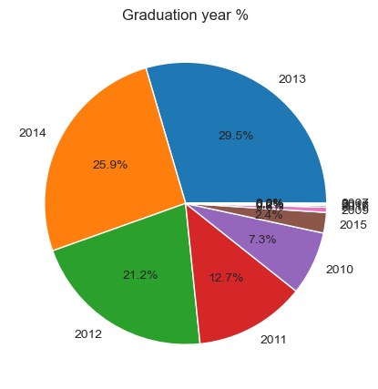

```python
plt.figure(figsize=(5,15))
plt.title('Graduation year %')
plt.pie(x=df['GraduationYear'].value_counts().to_list(),labels=df['GraduationYear'].value_counts().index,autopct='%1.1f%%')
```

### English

```python
df['English'].describe()
```

```
count    3998.000000
mean      501.649075
std       104.940021
min       180.000000
25%       425.000000
50%       500.000000
75%       570.000000
max       875.000000
Name: English, dtype: float64
```

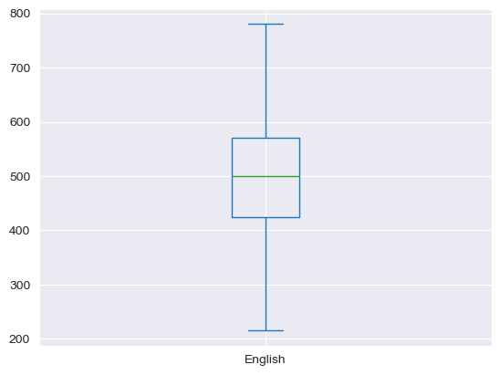

```python
df['English'][(df['English']>210)&(df['English']<790)].plot(kind='box')
```

```python
scaler = MinMaxScaler()
stand_marks = pd.DataFrame(index=df.index)  # Defining the index

# Standarize the 'English' column and assign it to 'stand_marks'
stand_marks['English'] = scaler.fit_transform(df[['English']])
```

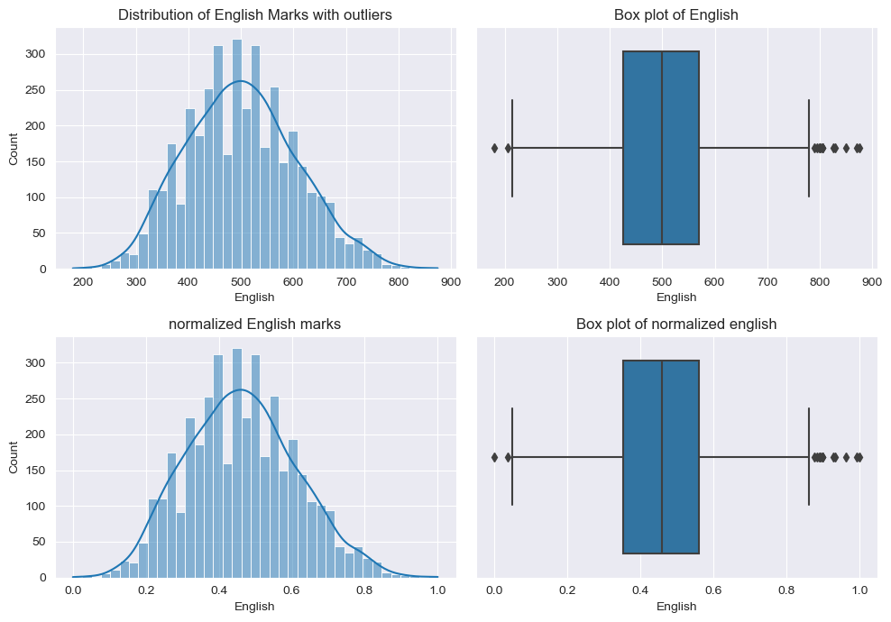

```python
plt.figure(figsize=(10,7))
plt.subplot(221)
plt.title('Distribution of English Marks with outliers')
sns.histplot(x=df['English'],kde=True)
plt.subplot(222)
plt.title('Box plot of English')
sns.boxplot(x=df['English'])
plt.subplot(223)
plt.title('normalized English marks')
sns.histplot(x=stand_marks['English'],kde=True)
plt.subplot(224)
plt.title('Box plot of normalized english')
sns.boxplot(x=stand_marks['English'])
plt.tight_layout()
```

#### Observation

- Distribution of English marks resemble normal distribution
- 75% of students scored less than 570 marks
- max marks scored is 875 and minimum marks scored=180

### Logical

```python
df['Logical'].describe()
```

```
count    3998.000000
mean      501.598799
std        86.783297
min       195.000000
25%       445.000000
50%       505.000000
75%       565.000000
max       795.000000
Name: Logical, dtype: float64
```

```python
stand_marks['Logical']=scaler.fit_transform(df[['Logical']])
```

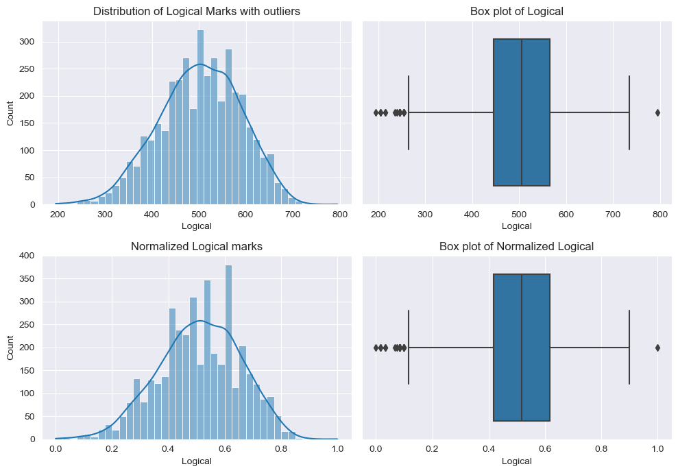

```python
plt.figure(figsize=(10,7))
plt.subplot(221)
plt.title('Distribution of Logical Marks with outliers')
sns.histplot(x=df['Logical'],kde=True)
plt.subplot(222)
plt.title('Box plot of Logical')
sns.boxplot(x=df['Logical'])
plt.subplot(223)
plt.title('Normalized Logical marks')
sns.histplot(x=stand_marks['Logical'],kde=True)
plt.subplot(224)
plt.title('Box plot of Normalized Logical')
sns.boxplot(x=stand_marks['Logical'])
plt.tight_layout()
```

#### Observation

- Logical Marks are left skwed and 75% candidates scored above 445

### Quant

```python
df['Quant'].describe()
```

```
count    3998.000000
mean      513.378189
std       122.302332
min       120.000000
25%       430.000000
50%       515.000000
75%       595.000000
max       900.000000
Name: Quant, dtype: float64
```

```python
stand_marks['Quant']=scaler.fit_transform(df[['Quant']])
```

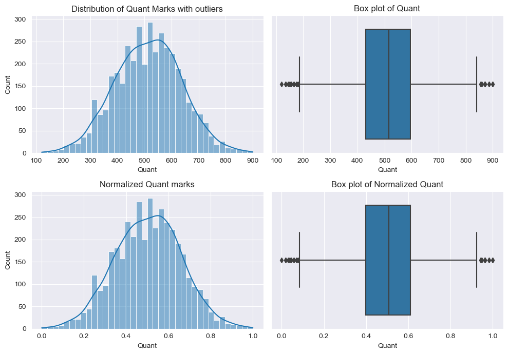

```python
plt.figure(figsize=(10,7))
plt.subplot(221)
plt.title('Distribution of Quant Marks with outliers')
sns.histplot(x=df['Quant'],kde=True)
plt.subplot(222)
plt.title('Box plot of Quant')
sns.boxplot(x=df['Quant'])
plt.subplot(223)
plt.title('Normalized Quant marks')
sns.histplot(x=stand_marks['Quant'],kde=True)
plt.subplot(224)
plt.title('Box plot of Normalized Quant')
sns.boxplot(x=stand_marks['Quant'])
plt.tight_layout()
```

#### Observation

- Quant marks are normally distributed
- 75% candidates scored less than 595 and max score is 900

```python
df['Quant'].describe()
```

```
count    3998.000000
mean      513.378189
std       122.302332
min       120.000000
25%       430.000000
50%       515.000000
75%       595.000000
max       900.000000
Name: Quant, dtype: float64
```

### Domain

```python
df['Domain'].describe()
```

```
count    3998.000000
mean        0.510490
std         0.468671
min        -1.000000
25%         0.342315
50%         0.622643
75%         0.842248
max         0.999910
Name: Domain, dtype: float64
```

```python
(df['Domain'][df['Domain']==-1].count()/len(df))*100
```

```
6.153076538269135
```

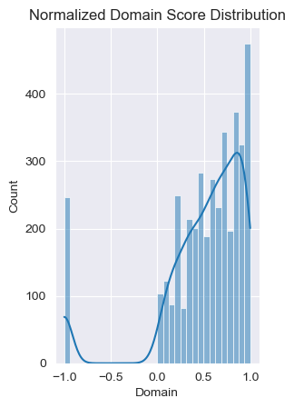

```python
plt.subplot(121)
sns.histplot(x=df['Domain'],kde=True)
plt.title('Normalized Domain Score Distribution')
```

#### Observation

- Normalized Domain Score is left skewed. If we ignore -1.
- 6.15 % of candidates didn't filled their domain scores.

### Computer Programming

```python
df['ComputerProgramming'].describe()
```

```
count    3998.000000
mean      353.102801
std       205.355519
min        -1.000000
25%       295.000000
50%       415.000000
75%       495.000000
max       840.000000
Name: ComputerProgramming, dtype: float64
```

```python
(df['ComputerProgramming'][df['ComputerProgramming']!=-1].count()/len(df))*100
```

```
78.28914457228613
```

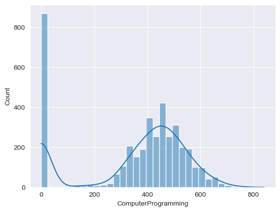

```python
sns.histplot(x=df['ComputerProgramming'],kde=True)
```

#### Observation

- 78.3 % of candidates attempted computer programming section
- Computer Programming scores are normally distributed